# How Much of a Dose Trajectory Does the Registry See? A Recall Study of ClinicalTrials.gov Against FDA Approval Packages

Jerry Hu

2026-08-13

← PK/PD Home Page

# 1 Summary

**Background.** Registry mining is a tempting shortcut for development intelligence: reconstruct a program’s dose-selection struggles from its ClinicalTrials.gov footprint alone. This study measures how much of that footprint actually exists. Using the FDA-enumerated study lists reconstructed in a companion study as the reference standard, it quantifies what fraction of eight approved antipsychotic programs’ studies — and of their dose-trajectory events — the registry captures.

**Methods.** The reference standard is the complete study enumeration from each program’s FDA approval package (clinical-pharmacology review for Phase 1, medical review for controlled trials, plus supplemental approvals), frozen before this analysis. The registry arm is a deterministic ClinicalTrials.gov API v2 scrape by all program identifiers (brand, INN, development codes), snapshotted with query and access date. Pre-specified matching rules were applied in order: NCT stated in an FDA document; sponsor study code in registry identifiers; phase + enrollment + conduct-window agreement; then documented manual adjudication. Recall is reported per phase with exact 95% confidence intervals; separately, 31 registry-expected dose-trajectory events were adjudicated for visibility from registry fields alone.

**Results.** Overall study-level recall was 38% (112/297). The pre-stated phase gradient appeared: Phase 1 recall 19% (36/188; 95% CI 14–26%), Phase 2 38% (15/39), Phase 3 85% (52/61; 95% CI 74–93%). Of 31 registry-expected trajectory events, 29 (94%) were visible from registry fields alone; regulatory events (complete response letters, approval actions) were structurally invisible.

**Conclusions.** The registry sees the trunk, not the roots: confirmatory trials are nearly fully recoverable, the early dose-finding record — where dose-selection struggles actually live — is mostly not. Registry-only reconstruction of a dose trajectory should be treated as a Phase-3 view with scattered fragments below.

# 2 Background

The companion study reconstructed the dose trajectories of modern antipsychotic programs from the full evidence record — FDA approval packages, archived labels, publications. A natural question for anyone doing competitive or methodological intelligence is whether the expensive part was necessary: how much of a program’s dose story could be recovered from ClinicalTrials.gov alone?

The registry’s blind spots are structural, not accidental. FDAAA 801 exempts Phase 1 trials from mandatory registration; regulatory correspondence (complete response letters, end-of-Phase-2 verdicts) has no registry object; and label changes leave a registry trace only when a new trial produced them. This study turns those expectations into measured recall, using a reference standard that is — for approved programs — legally complete: the sponsor’s own study enumeration as audited in the FDA approval package.

**Objective.** Quantify, per program and per phase, the fraction of FDA-enumerated studies findable in ClinicalTrials.gov (study-level recall); the fraction of dose-trajectory events visible from registry fields alone (event-level recall); and the timing fidelity of what is found.

# 3 Methods

## 3.1 Reference standard

The frozen extraction tables of the companion study (297 FDA-enumerated study rows across the eight approved programs; see its report for extraction methodology) serve as the reference standard. A study enters the recall denominator only if it is traceable to an FDA approval package, supplemental approval, or label — the registry must be findable against the regulator’s audited list, not against itself. Ulotaront (terminated; no FDA package exists) is excluded from the formal metric and described narratively. Two upstream fences protected this design: registry identifiers entered the reference standard only when stated in FDA documents or publications, and the scrape below was executed *before* the companion study’s deep document reading.

## 3.2 Registry arm

ClinicalTrials.gov API v2 was queried per program identifier — brand name, INN, and development codes (ITI-007, SEP-363856, SM-13496, OPC-34712, RGH-188, MP-214, ALKS 3831, ALKS 33, KarXT, HP-873, Org 5222) — with no condition filter, so the full program footprint including healthy-volunteer work is captured. Raw study JSON was snapshotted (gzipped, with the exact queries and access timestamp recorded); 512 unique registry records resulted. The identifier set was amended once, before results were finalized: manual adjudication surfaced five registered studies titled only by development codes missing from the initial query list (MP-214, the Japanese cariprazine code; ALKS 33, samidorphan alone), and the scrape was re-run with the completed set. The incident is reported below because it is itself a finding about registry mining. Parsed fields include titles, sponsor and secondary identifiers, phases, enrollment, arm/intervention dose text, dates, and results-posting status.

## 3.3 Matching rules (pre-specified, applied in order; first hit wins)

1. **R1 — NCT stated in an FDA document** (confidence A).
2. **R2 — sponsor study code appears in the registry record’s organization/secondary identifiers**, normalized for punctuation (confidence A).
3. **R3 — same program, same phase, enrollment within ±20%, plus corroboration: conduct windows within 18 months when both dates are known, or at least one shared numeric dose value between the reference arms and the registry arm text when dates are unknown** (confidence B; one registry record can be claimed once; ambiguous candidates logged).
4. **R4 — manual adjudication**, each with a documented justification (confidence C).

Unmatched reference studies count as registry misses. Registry records matching no reference study are tabulated as registry-only and described.

## 3.4 Metrics

Study-level recall per phase and program, with Clopper–Pearson exact 95% confidence intervals on pooled phase estimates. Event-level recall over the companion study’s trajectory events pre-flagged as plausibly registry-visible, adjudicated against registry fields alone (the revealing field recorded per event); label-only events are reported separately as structurally invisible. Timing: months from study start to registry submission (prospective = within 30 days), and results-posting lag. All estimates are descriptive; no hypothesis tests.

# 4 Results

## 4.1 Study-level recall: the phase gradient

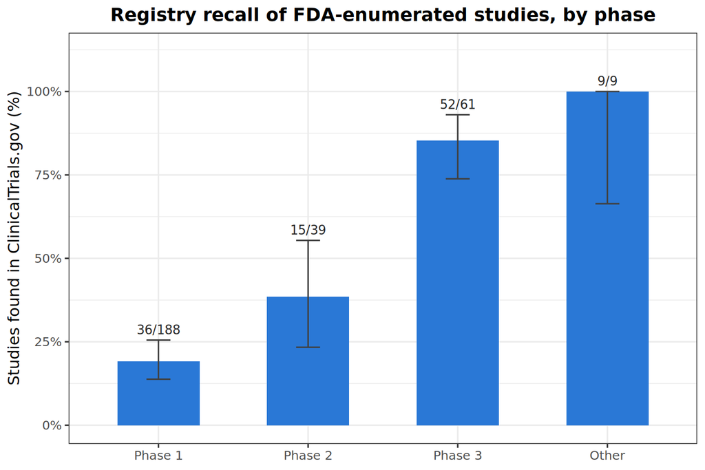

Registry recall of FDA-enumerated studies by phase, pooled over the eight approved programs. Error bars are Clopper–Pearson exact 95% CIs; labels give matched/enumerated counts.

The pre-stated expectation held: recall climbs from 19% (36/188; 95% CI 14–26%) in Phase 1 to 85% (52/61; 95% CI 74–93%) in Phase 3. The registry is close to complete exactly where the dose range has already been chosen, and thinnest where the choosing happened.

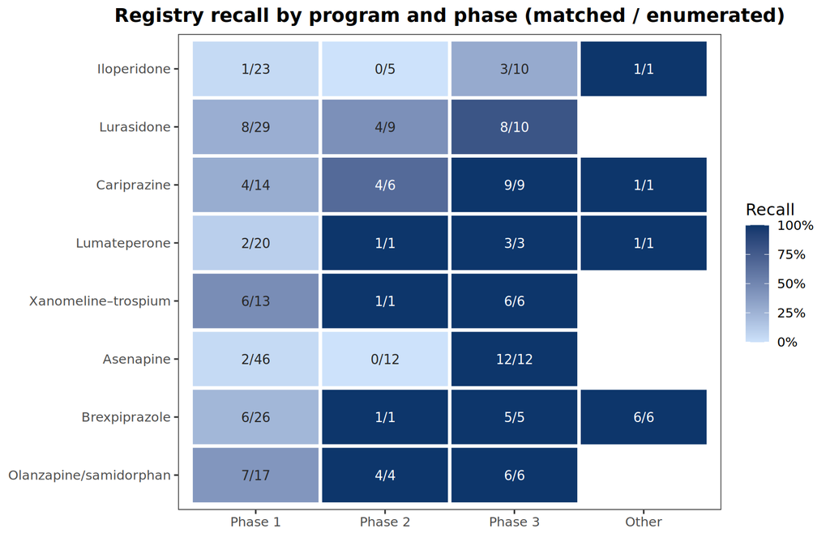

Recall by program and phase. Cell labels give matched/enumerated studies; darker = higher recall.

Study-level recall by program and phase (matched / FDA-enumerated).

| Program | Phase | Enumerated | Matched | Recall (%) |
| --- | --- | --- | --- | --- |
| Olanzapine/samidorphan | Phase 1 | 17 | 7 | 41 |
|  | Phase 2 | 4 | 4 | 100 |
|  | Phase 3 | 6 | 6 | 100 |
| Brexpiprazole | Phase 1 | 26 | 6 | 23 |
|  | Phase 2 | 1 | 1 | 100 |
|  | Phase 3 | 5 | 5 | 100 |
|  | Other | 6 | 6 | 100 |
| Asenapine | Phase 1 | 46 | 2 | 4 |
|  | Phase 2 | 12 | 0 | 0 |
|  | Phase 3 | 12 | 12 | 100 |
| Xanomeline–trospium | Phase 1 | 13 | 6 | 46 |
|  | Phase 2 | 1 | 1 | 100 |
|  | Phase 3 | 6 | 6 | 100 |
| Lumateperone | Phase 1 | 20 | 2 | 10 |
|  | Phase 2 | 1 | 1 | 100 |
|  | Phase 3 | 3 | 3 | 100 |
|  | Other | 1 | 1 | 100 |
| Cariprazine | Phase 1 | 14 | 4 | 29 |
|  | Phase 2 | 6 | 4 | 67 |
|  | Phase 3 | 9 | 9 | 100 |
|  | Other | 1 | 1 | 100 |
| Lurasidone | Phase 1 | 29 | 8 | 28 |
|  | Phase 2 | 9 | 4 | 44 |
|  | Phase 3 | 10 | 8 | 80 |
| Iloperidone | Phase 1 | 23 | 1 | 4 |
|  | Phase 2 | 5 | 0 | 0 |
|  | Phase 3 | 10 | 3 | 30 |
|  | Other | 1 | 1 | 100 |

## 4.2 How the matches were made

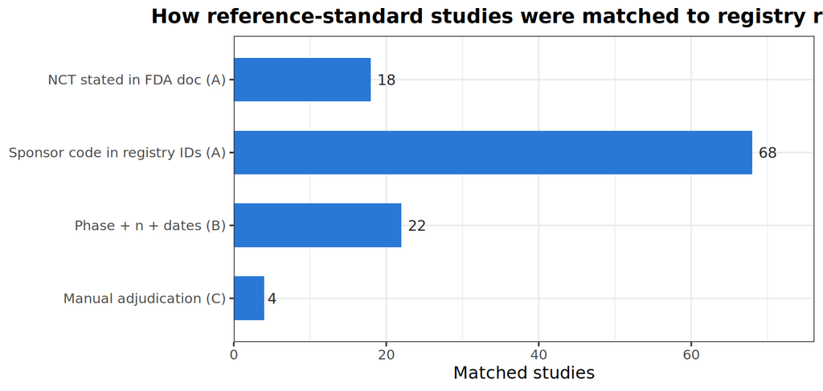

Match-rule breakdown for the matched studies (rule applied first-hit-wins; letters are confidence grades).

86 matches carry confidence A (a stated NCT or an exact sponsor code in the registry’s identifier fields), 22 rest on the B-grade phase/enrollment/window rule, and 4 required manual adjudication. That the plurality of matches needed the sponsor-code rule is itself a registry-usability finding: the linkage lives in the `secondary ID` field, not in anything searchable by dose.

## 4.3 Event-level recall: what a registry-only analyst would see

Event-level recall: dose-trajectory events plausibly visible in the registry, vs those actually visible from registry fields alone.

| Program | Registry-expected events | Visible in registry | Recall (%) |
| --- | --- | --- | --- |
| Cariprazine | 2 | 1 | 50 |
| Iloperidone | 3 | 2 | 67 |
| Lumateperone | 5 | 5 | 100 |
| Lurasidone | 5 | 5 | 100 |
| Ulotaront | 15 | 15 | 100 |
| Xanomeline–trospium | 1 | 1 | 100 |

Which registry field reveals a visible event.

| Revealing registry field | Events |
| --- | --- |
| arm-dose-text | 18 |
| new-trial-registration | 9 |
| sponsor-field | 1 |
| why-stopped | 1 |

Of 31 events pre-flagged as plausibly registry-visible, 29 (94%) could be read from registry fields alone — mostly through the dose text of newly registered trials (a higher-dose arm appearing; a dedicated dose-reduction trial). The other 56 of the companion study’s 87 events were label-only or regulatory and were never candidates: complete response letters, approval actions, and label edits have no registry object at all. A registry-only analyst would see lurasidone’s 160 mg arms appear in new trials, but not *why* the 80 mg cap existed; they would see cariprazine’s dose-reduction maintenance trial, but not the metabolite finding and the FDA request that motivated it.

## 4.4 Timing and the registry-only remainder

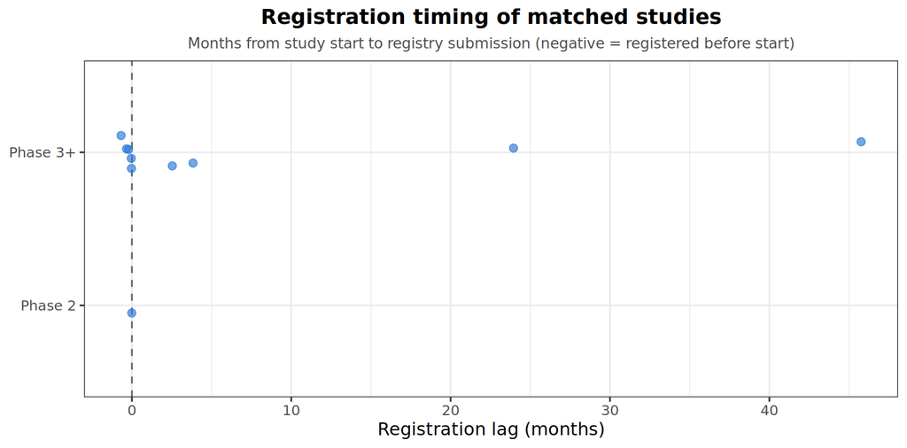

Registration lag of matched studies (each point one study; negative = prospectively registered before study start).

Registry records not matched to the reference standard, per program. For programs with a reference standard these are other-indication trials, investigator-initiated studies, and post-approval work outside the schizophrenia scope; for ulotaront no reference standard exists.

| Program | Registry records not matched to the reference standard | Reference standard exists |
| --- | --- | --- |
| Asenapine | 45 | Yes |
| Brexpiprazole | 85 | Yes |
| Cariprazine | 46 | Yes |
| Iloperidone | 29 | Yes |
| Lumateperone | 29 | Yes |
| Lurasidone | 79 | Yes |
| Olanzapine/samidorphan | 22 | Yes |
| Ulotaront | 29 | No (terminated program) |
| Xanomeline–trospium | 39 | Yes |

The unmatched registry records are not noise: they are dominated by other-indication trials (bipolar, MDD adjunct), investigator-initiated studies, and post-approval Phase 4 work outside this study’s adult-schizophrenia scope — a reminder that a raw identifier scrape over-collects relative to any one question.

## 4.5 Ulotaront, descriptively

The terminated program inverts the picture. With no FDA package, the registry *is* the primary record: all of its Phase 2 and Phase 3 trials are registered, with results posted for the failed DIAMOND trials, and its dose story (flexible 50–75 mg/day in Phase 2; fixed 50/75 and 75/100 mg/day in Phase 3; a 2025 restart keeping only 75/100 mg) is fully legible from registry fields. Its Phase 1 program, however, is known only in aggregate — its population-PK publication pools seven Phase 1 studies of which several appear nowhere in the registry. For failed programs the registry is the best public enumeration available and still incomplete at the roots.

# 5 Discussion

**The registry sees the trunk, not the roots.** Recall rises monotonically with phase. The confirmatory record is essentially public; the dose-finding record — MTD escalations, PET occupancy studies, the food-effect and DDI work that shapes a label’s schedule — is recoverable only in fragments. This is the designed consequence of FDAAA 801’s Phase 1 exemption, here given numbers.

**“Interpolating struggles” from the registry works only where the struggle produced a new trial.** The event-level result is the sharper one: registry visibility requires a trial-shaped consequence. Dose caps argued in review documents, letters demanding high-dose safety data, kinetic language added to labels — the causal tissue of the companion study’s trajectories — never touch the registry. Where the struggle did produce a trial (lurasidone’s 80-vs-160 program, cariprazine’s dose-reduction study), the registry shows the response but not the question.

## 5.1 Limitations

- The reference standard, while FDA-audited, is bounded by what approval packages enumerate: studies abandoned before submission would be missing from both sides and cannot be counted as misses.
- Matching rule R3 (phase/enrollment/window) is fallible in both directions; its matches carry confidence B and ambiguous candidates were logged rather than forced.
- The three context programs’ enumerations were extracted for this study’s denominator with the same method as the deep-reconstruction programs but received no independent second pass.
- The scrape is a single snapshot (August 2026); registry edits after that date are out of scope.
- Cross-registry coverage (EudraCT, JapicCTI) was consulted only as a cross-check; formal recall against WHO ICTRP was not computed, which penalizes programs with Japanese early development (lurasidone) in the CT.gov-only metric. This is a measurement of *ClinicalTrials.gov*, not of global registration.

# 6 Reproducibility

The scrape records its exact API queries and access timestamp beside the raw JSON snapshot; the matching and recall pipeline is deterministic from the frozen reference standard (provenance: source commit, freeze date, and file hashes recorded alongside the imported tables). No stochastic step exists; no seed is required. All stage scripts and curated adjudication files are version-controlled.

*Data & code availability: the raw registry snapshot (gzipped JSON with query manifest), parsed records, matching outputs, adjudication files, and all stage scripts are maintained in the project repository. Companion study: the dose trajectories themselves.*